# Trp53cor1 KO vs WT (Male_leg)

# Gene/Pathway Analysis

## GSEA

Enrichment and zscores are calculated based on expression in KO vs WT (fpkmKO/fpkmWT), so genes that are down regulated in KO are shown in blue, while upregulation is shown in red.

KO/WT Blue = down in KO Red = Up in KO

Biocarta enrichment:

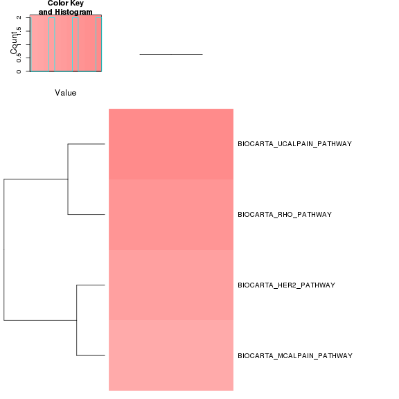

Biocarta zscore:

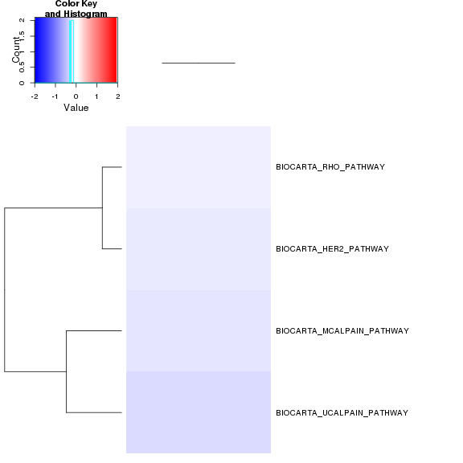

Reactome enrichment:

[output not shown]

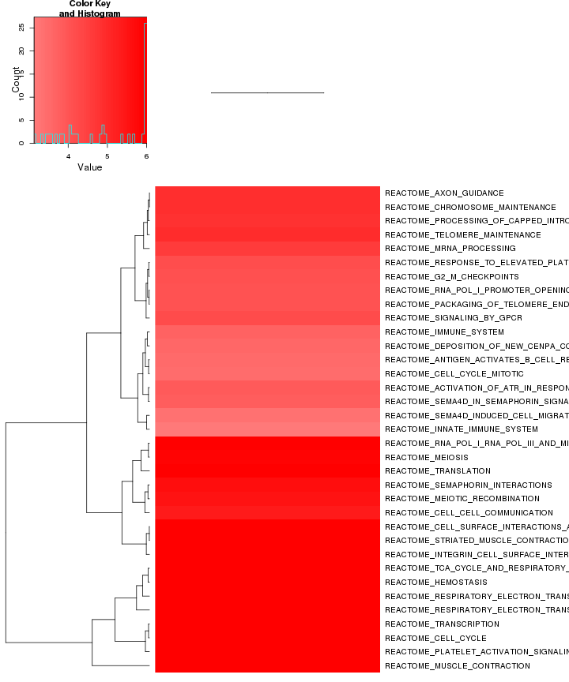

Reactome zscore:

[output not shown]

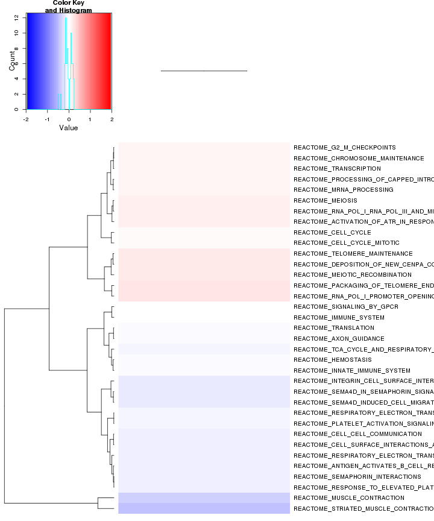

Kegg enrichment:

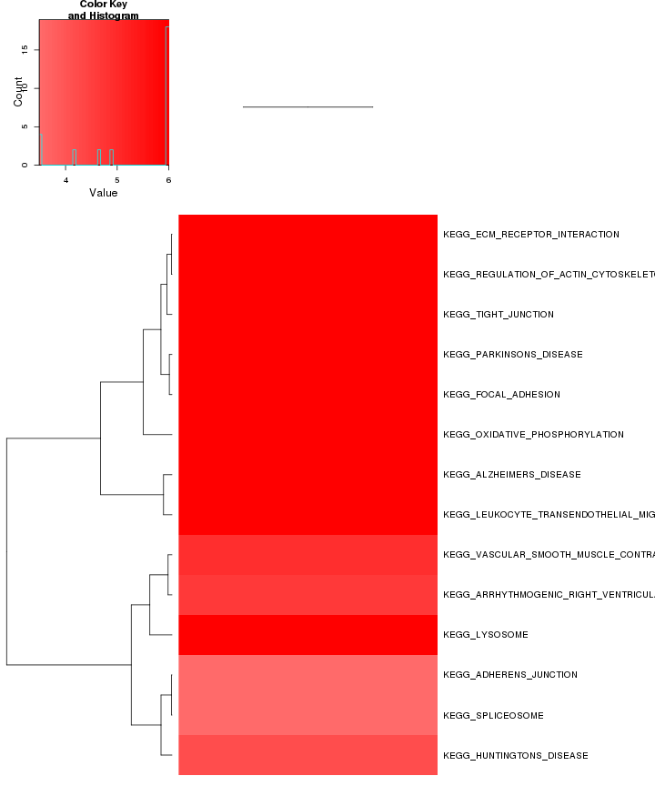

Kegg zscore:

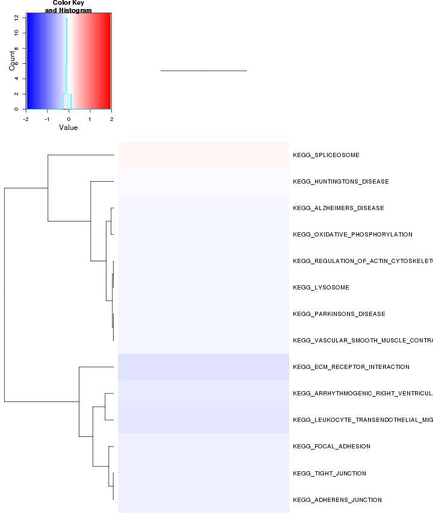

p53 enrichment:

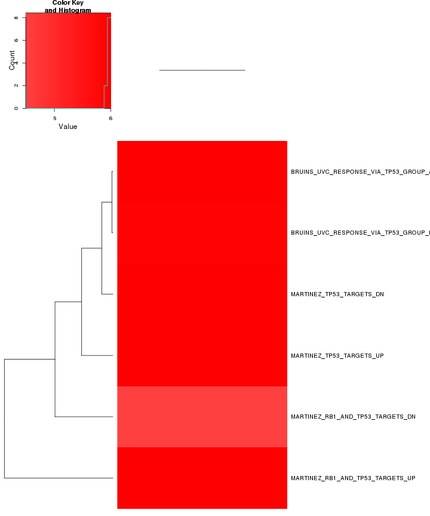

p53 zscore:

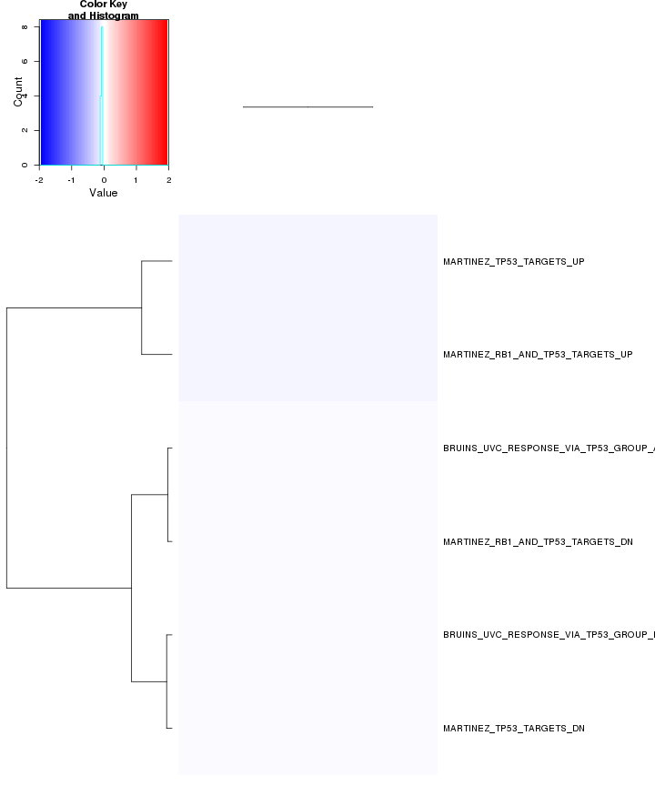

Oncogene enrichment:

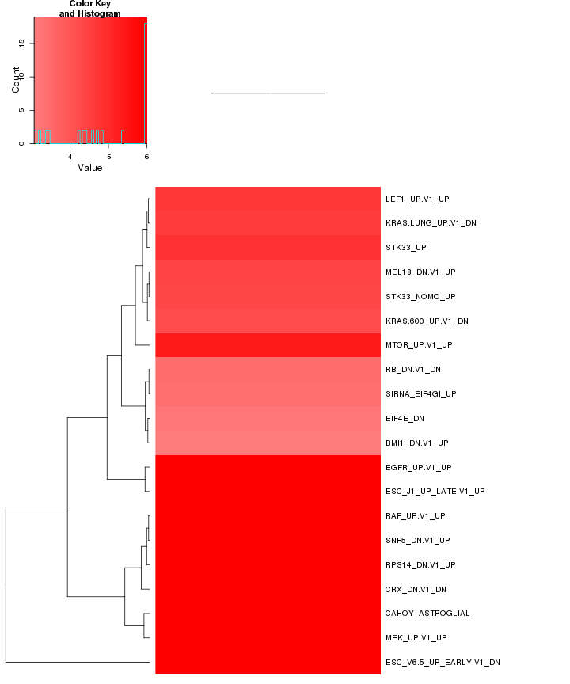

Oncogene zscore:

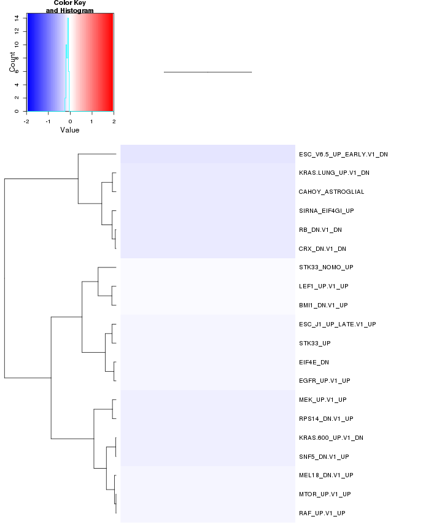

Jacks enrichment

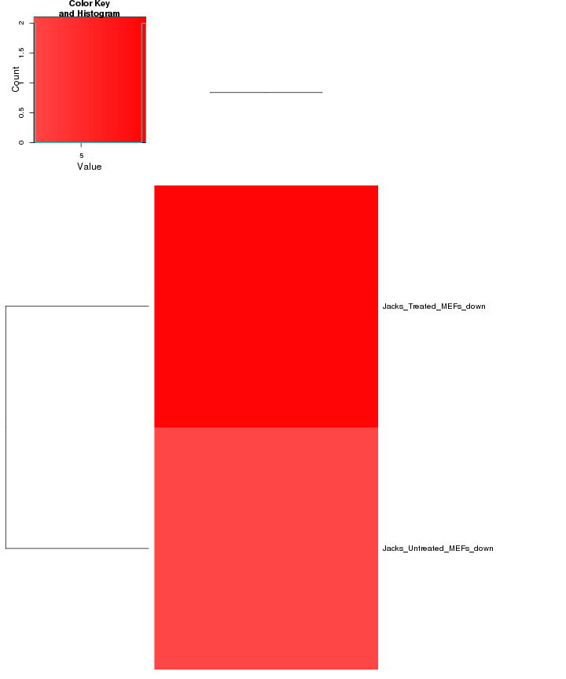

Jacks zscore

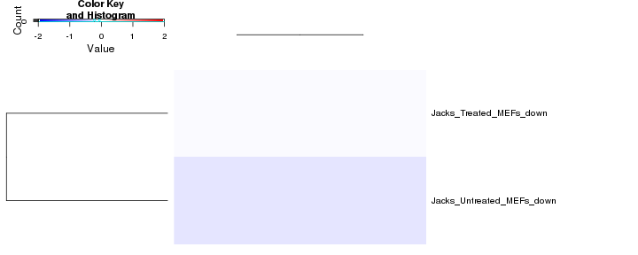

All enrichment

There are 842 categories enriched (p<0.0001). They are:

[output not shown]

[figure not shown]

ALL zscore:

[output not shown]

[figure not shown]

## GO enrichment

Cluster profiler used to call enichments of significantly differentially regulated genes that map to Entrez IDs.

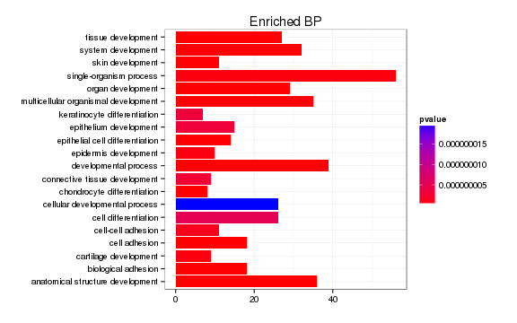

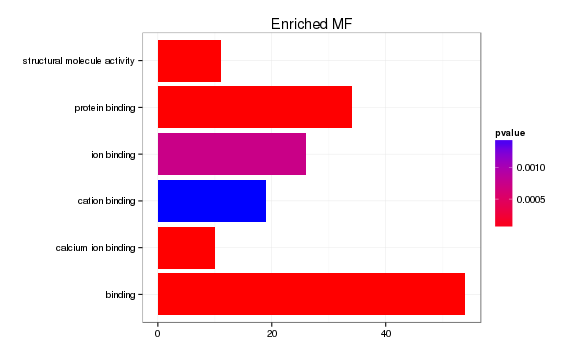

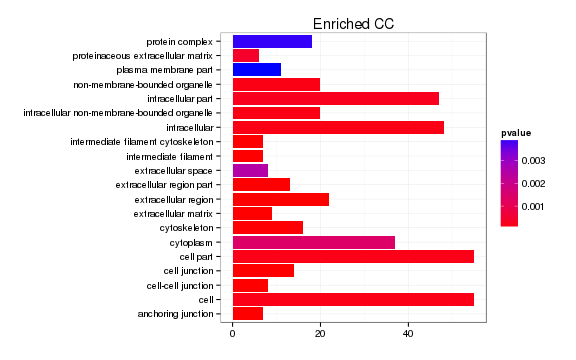

[output not shown]

# Cis vs Trans (locally)

log2 Foldchange and test statistic are calculated with the ratio of fpkm(KO)/fpkm(WT), thus the test_stat is positive if a gene is higher in the KO and negative if a gene has lower expression in the KO

The pvalue for genes significantly regulated in a region this size is: 0.052

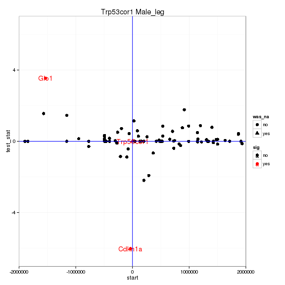

# Notes

## Samples used are:

|  | 11 |
| --- | --- |
| 1 | JR878 |
| 2 | JR881 |
| 3 | JR883 |
| 4 | lincp21_Leg_KO4 |

## Replicates

|  | file | sample_name | replicate | rep_name | total_mass | norm_mass | internal_scale | external_scale |
| --- | --- | --- | --- | --- | --- | --- | --- | --- |
| 1 | /n/rinn_data1/users/agroff/seq/OtherMice/Diana/lincP21/quants/JR878/abundances.cxb | WT | 0 | WT_0 | 48224900.00 | 38745900.00 | 1.22 | 1.00 |
| 2 | /n/rinn_data1/users/agroff/seq/OtherMice/Diana/lincP21/quants/JR881/abundances.cxb | WT | 1 | WT_1 | 43230900.00 | 38745900.00 | 1.11 | 1.00 |
| 3 | /n/rinn_data1/users/agroff/seq/OtherMice/Diana/lincP21/quants/JR883/abundances.cxb | Trp53cor1 | 0 | Trp53cor1_0 | 53017900.00 | 38745900.00 | 1.37 | 1.00 |
| 4 | /n/rinn_data1/users/agroff/seq/OtherMice/Diana/lincP21/quants/lincp21_Leg_KO4/abundances.cxb | Trp53cor1 | 1 | Trp53cor1_1 | 20607100.00 | 38745900.00 | 0.55 | 1.00 |

## Run Info

[output not shown]